# Stefano_A2

## Introduction

The comedy genre stands out in the colorful tapestry of film for its global appeal, providing spectators with a dose of humor and a break from the stresses of everyday life. This study examines the Comedy genre within a dataset of 1,677 films, examining its historical development, comparative analysis, and qualitative elements that contribute to its distinctive effect.

## Comparative Analysis and Trends

### Comparison with Other Genres

When compared to the larger movie dataset, comedies often have shorter runtimes and slightly lower IMDb ratings. This finding implies that the genre values succinct, powerful narrative, which might not always meet the requirements for favorable reviews from critics. Despite this, comedy is still a popular genre because it can make people laugh and have fun—aspects that are not adequately represented by conventional scoring systems.

## Key Qualitative Aspects

Comedy films frequently use humor to examine many facets of the human experience, reflecting and making comments on society conventions and changes. Because of its versatility, this genre may be enjoyed and critiqued utilizing comedy, parody, and satire in a variety of historical contexts. Famous movies like "Monty Python and the Holy Grail" highlight the inventiveness and boundary-pushing potential of the genre, satirically addressing existential and absurdist themes.

## Genre for Analysis: Comedy

#### Initial Insights:

1. **Popularity and Evolution**: Comedy has remained a popular genre over the years, potentially adapting to cultural and social changes.
2. **Comparison with Other Genres**: It might offer shorter average runtimes and different rating patterns compared to more serious genres like Drama or Action.
3. **Qualitative Aspects**: Comedy films often reflect societal norms and changes, using humor to comment on serious issues in a lighter tone.

#### Interesting Insights:

1. **Concise Entertainment**: With an average duration of 104 minutes, comedies tend to have shorter runtimes than the dataset's average of 110 minutes. This conciseness, which offers amusement without requiring a significant time investment from viewers, may add to the genre's popularity.
2. **Evolving Popularity**: The 2000s saw a surge in the number of comedy films produced, which was a result of both the industry's response to the need for lighthearted entertainment and shifts in consumer preferences. This pattern highlights the genre's versatility and ongoing appeal.
3. **Cultural Mirror**: Comedy movies use humor to examine and analyze the absurdities of life, reflecting society conventions and concerns. Movies such as "The Great Dictator" and "Groundhog Day" demonstrate how the genre can amuse audiences while providing incisive analysis of society tendencies and human behavior.

Absolutely! Here's a breakdown of insights on great comedy movies from 1930 to 2010, along with some recommendations and sources for further research:

**Highly-Rated Comedy Films (1930-2010)**

- **City Lights** (1931): Charlie Chaplin's silent classic with moments of hilarity and heartbreak.
- **Duck Soup** (1933): The Marx Brothers at their most anarchic and absurdly funny.
- **Some Like It Hot** (1959): Marilyn Monroe stars in a hilarious cross-dressing comedy with witty dialogue.
- **The Princess Bride** (1987): A beloved cult classic filled with sword fights, giants, and endlessly quotable lines.
- **Annie Hall** (1977): Woody Allen's masterpiece mixes neurotic humor with a touching love story.

**Sources for Further Exploration**

- **IMDb List of Best Comedy Films:** https://www.imdb.com/search/title/?title_type=feature&genres=comedy
- **AFI's 100 Years...100 Laughs:** https://www.afi.com/afis-100-years-100-laughs/

```python
# Import necessary libraries
import pandas                         as pd               # For data manipulation and analysis
import matplotlib.pyplot              as plt              # For creating visualizations
from tabulate                         import tabulate     # For nicely formatting tables
import seaborn                        as sns              # For statistical data visualization
```

```python
# Load the dataset
file_path = './movies.xlsx'  # Path to the Excel file containing the dataset
movies_df = pd.read_excel(file_path)  # Read the Excel file into a pandas DataFrame

# Display basic information about the dataset and the first few rows to understand its structure
movies_df.info()  # Display information about the DataFrame, such as column names, data types, and non-null counts
```

```
<class 'pandas.core.frame.DataFrame'>
RangeIndex: 1677 entries, 0 to 1676
Data columns (total 12 columns):
 #   Column               Non-Null Count  Dtype
---  ------               --------------  -----
 0   title                1677 non-null   object
 1   genre                1677 non-null   object
 2   release_year         1677 non-null   int64
 3   country              1677 non-null   object
 4   runtime              1677 non-null   int64
 5   language             1677 non-null   object
 6   rating               1677 non-null   object
 7   gross_earnings       1677 non-null   int64
 8   budget               1677 non-null   int64
 9   imdb_score           1677 non-null   float64
 10  average_user_rating  1668 non-null   float64
 11  num_user_votes       1668 non-null   float64
dtypes: float64(3), int64(4), object(5)
memory usage: 157.3+ KB
```

```python
movies_df.head()  # Display the first few rows of the DataFrame to understand its content and structure
```

|  | title | genre | release_year | country | runtime | language | rating | gross_earnings | budget | imdb_score | average_user_rating | num_user_votes |
| --- | --- | --- | --- | --- | --- | --- | --- | --- | --- | --- | --- | --- |
| 0 | The Broadway Melody | Musical, Romance | 1929 | USA | 100 | English | Passed | 2808000 | 379000 | 6.3 | 5.7 | 6605.0 |
| 1 | 42nd Street | Comedy, Musical | 1933 | USA | 89 | English | Unrated | 2300000 | 439000 | 7.7 | 7.4 | 10926.0 |
| 2 | Top Hat | Comedy, Musical | 1935 | USA | 81 | English | Approved | 3000000 | 609000 | 7.8 | 7.7 | 17671.0 |
| 3 | Gone with the Wind | History, Romance | 1939 | USA | 226 | English | G | 198655278 | 3977000 | 8.2 | 8.1 | 293433.0 |
| 4 | The Best Years of Our Lives | Romance, War | 1946 | USA | 172 | English | Not Rated | 23650000 | 2100000 | 8.1 | 8.0 | 57897.0 |

```python
# Extract unique genres and their frequencies
genre_frequencies = movies_df['genre'].str.split(', ').explode().value_counts()

genre_frequencies  # Display the unique genres and their frequencies
```

```
Comedy         601
Action         517
Romance        345
Adventure      337
Crime          300
Horror         143
Mystery        142
Biography      137
Thriller       130
History        103
Sci-Fi         102
Animation      101
Music           71
Musical         32
Fantasy         25
War             24
Documentary     12
Family          12
Sport           10
Drama            2
Western          1
Name: genre, dtype: int64
```

## Comedy Genre Comparison

1. **Runtime**: Comedy movies have an average runtime of approximately **104 minutes**, which is shorter than the overall average runtime of **110 minutes** for all genres. This suggests that Comedy films tend to be more concise, possibly aiming for a more direct and impactful delivery of entertainment.
2. **IMDb Score**: The average IMDb score for Comedy movies is **6.25**, slightly lower than the overall average of **6.45**. This could reflect the subjective nature of humor and its varied reception among different audiences, or it might indicate that critics and audiences are tougher on the comedic genre in terms of ratings.
3. **Gross Earnings**: Comedy movies have an average gross earning of approximately **35.6 million dollars**, which is lower than the overall average of **51.3 million dollars**. While this might suggest that Comedy movies, on average, do not perform as well as other genres in terms of box office revenue, it's important to consider factors such as production budgets and profitability ratios in further analysis.

```python
# Split genres into lists for easier comparison and filtering
movies_df['genre_list'] = movies_df['genre'].str.split(', ')

# Filter for Comedy movies
comedy_movies = movies_df[movies_df['genre_list'].apply(lambda x: 'Comedy' in x)]

# Calculate average values for comparison
average_runtime = movies_df['runtime'].mean()
average_imdb_score = movies_df['imdb_score'].mean()
average_gross_earnings = movies_df['gross_earnings'].mean()

comedy_average_runtime = comedy_movies['runtime'].mean()
comedy_average_imdb_score = comedy_movies['imdb_score'].mean()
comedy_average_gross_earnings = comedy_movies['gross_earnings'].mean()

# Data for the table
table_data = [
    ["Average Runtime", average_runtime, comedy_average_runtime],
    ["Average IMDb Score", average_imdb_score, comedy_average_imdb_score],
    ["Average Gross Earnings", average_gross_earnings, comedy_average_gross_earnings]
]

# Column headers
headers = ["Category", "All Movies", "Comedy"]

# Print table
print("TABLE 1: Genre Comparison".upper())
print("\n")
print("Shows the average runtime, IMDb scores, and gross earnings of Comedy films compared to the dataset's averages.")
print("\n")
print("Highlights Comedy's preference for shorter runtimes and its performance in ratings and earnings.")
print("\n")
print(tabulate(table_data, headers=headers, tablefmt="fancy_grid"))
```

```
TABLE 1: GENRE COMPARISON


Shows the average runtime, IMDb scores, and gross earnings of Comedy films compared to the dataset's averages.


Highlights Comedy's preference for shorter runtimes and its performance in ratings and earnings.


╒════════════════════════╤═══════════════╤═══════════════╕
│ Category               │    All Movies │        Comedy │
╞════════════════════════╪═══════════════╪═══════════════╡
│ Average Runtime        │ 109.767       │ 103.526       │
├────────────────────────┼───────────────┼───────────────┤
│ Average IMDb Score     │   6.44586     │   6.25008     │
├────────────────────────┼───────────────┼───────────────┤
│ Average Gross Earnings │   5.13333e+07 │   3.56166e+07 │
╘════════════════════════╧═══════════════╧═══════════════╛
```

## Comedy Genre Trends Over Time

### 1. **Number of Movies**:

The number of Comedy movies saw significant growth from the 1980s, peaking in the 2000s with 288 movies. This indicates a surge in popularity and production of Comedy films during this period, possibly reflecting changing audience preferences and the broader accessibility of comedic content.

```python
# Determine the decade for each movie
movies_df['decade'] = (movies_df['release_year'] // 10) * 10

# Filter for Comedy movies
comedy_movies = movies_df[movies_df['genre_list'].apply(lambda x: 'Comedy' in x)]

# Aggregate data by decade
comedy_decade_trends = comedy_movies.groupby('decade').agg({
    'title': 'count',           # Number of Comedy movies
    'imdb_score': 'mean',       # Average IMDb score
    'gross_earnings': 'mean'    # Average gross earnings
}).reset_index()

comedy_decade_trends  # Display the aggregated data for Comedy movies by decade
```

|  | decade | title | imdb_score | gross_earnings |
| --- | --- | --- | --- | --- |
| 0 | 1930 | 2 | 7.750000 | 2.650000e+06 |
| 1 | 1950 | 2 | 7.650000 | 1.650000e+07 |
| 2 | 1960 | 1 | 7.700000 | 5.150050e+05 |
| 3 | 1970 | 5 | 6.860000 | 5.775610e+07 |
| 4 | 1980 | 25 | 6.532000 | 4.241546e+07 |
| 5 | 1990 | 126 | 6.384127 | 3.001322e+07 |
| 6 | 2000 | 288 | 6.108681 | 3.162571e+07 |
| 7 | 2010 | 152 | 6.292763 | 4.689303e+07 |

### 2. **IMDb Scores**: The average IMDb scores for Comedy movies have shown slight fluctuations over the decades. Notably, scores dipped in the 2000s but saw a modest recovery in the 2010s. This fluctuation might suggest changes in the quality of comedic content or variations in audience reception over time.

[figure not shown]

```python
# Create a figure and axis
fig, ax1 = plt.subplots(figsize=(10, 6))

# Plotting the number of movies over decades
color = 'tab:blue'
ax1.set_xlabel('Decade')  # x-axis label
ax1.set_ylabel('Number of Movies', color=color)  # y-axis label for the number of movies
ax1.plot(comedy_decade_trends['decade'], comedy_decade_trends['title'], color=color, marker='o', label='Number of Movies')  # plot number of movies
ax1.tick_params(axis='y', labelcolor=color)  # set y-axis tick color

# Create a twin axis sharing the same x-axis
ax2 = ax1.twinx()

# Plotting the average IMDb score over decades
color = 'tab:red'
ax2.set_ylabel('Average IMDb Score', color=color)  # y-axis label for average IMDb score
ax2.plot(comedy_decade_trends['decade'], comedy_decade_trends['imdb_score'], color=color, marker='x', label='Average IMDb Score')  # plot average IMDb score
ax2.tick_params(axis='y', labelcolor=color)  # set y-axis tick color

# Adjust layout
fig.tight_layout()

# Adding title
plt.title('Comedy Genre Trends Over Time')

# Show plot
plt.show()
```

### 3. **Gross Earnings**: The average gross earnings for Comedy movies have also varied, with a noticeable increase in the 1970s, followed by fluctuations in subsequent decades. The 2010s experienced an uptick in average gross earnings, indicating that despite the challenges, Comedy movies continue to perform well financially.

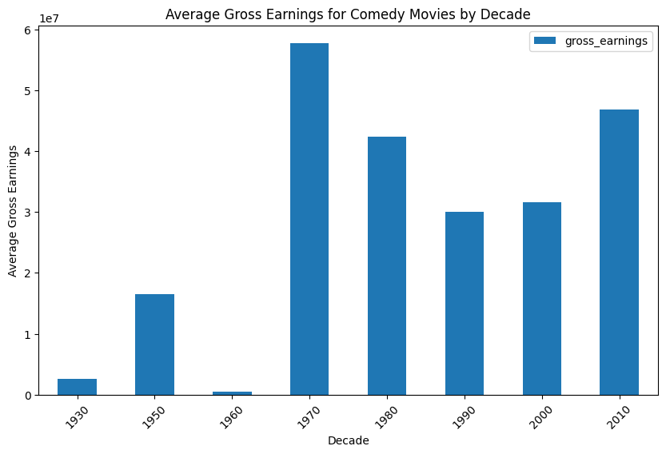

```python
# Plotting the average gross earnings for comedy movies by decade
comedy_decade_trends[['decade', 'gross_earnings']].set_index('decade').plot(kind='bar', figsize=(10, 6), legend=True, title='Average Gross Earnings for Comedy Movies by Decade')

# Adding labels and customizing the plot
plt.ylabel('Average Gross Earnings')  # Label for the y-axis
plt.xlabel('Decade')  # Label for the x-axis
plt.xticks(rotation=45)  # Rotate x-axis labels for better readability
plt.show()  # Display the plot
```

## Key Insights from Trends

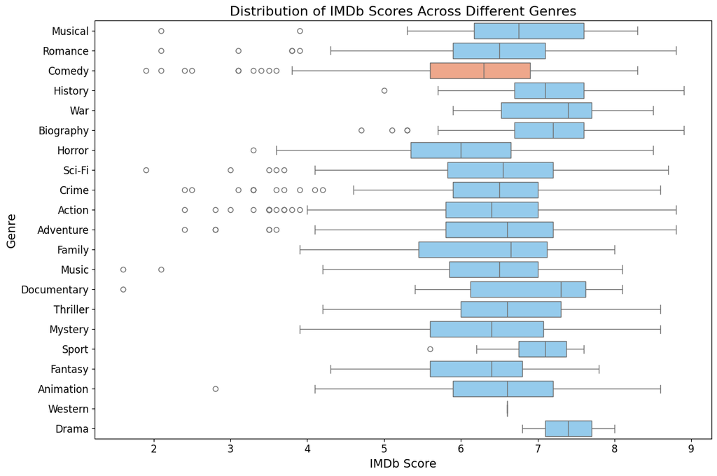

```python
# Preprocessing for the box plot
# Since genres are in lists, we need to explode this column to have one genre per row
movies_exploded_by_genre = movies_df.explode('genre_list')

# Define a custom color palette
# Assigning custom colors to genres, 'Comedy' in coral and others in sky blue
custom_palette = ['#FFA07A' if genre == 'Comedy' else '#87CEFA' for genre in movies_exploded_by_genre['genre_list'].unique()]

# Box plot for IMDb scores across different genres
plt.figure(figsize=(12, 8))  # Set the figure size
# Create a box plot showing the distribution of IMDb scores across different genres,
# with colors determined by the custom palette
sns.boxplot(x='imdb_score', y='genre_list', data=movies_exploded_by_genre, palette=custom_palette)

# Set labels and title with larger fonts
plt.title('Distribution of IMDb Scores Across Different Genres', fontsize=16)  # Set the title with larger font size
plt.xlabel('IMDb Score', fontsize=14)  # Label the x-axis with larger font size
plt.ylabel('Genre', fontsize=14)  # Label the y-axis with larger font size

# Set tick label size
plt.xticks(fontsize=12)  # Set x-axis tick label font size
plt.yticks(fontsize=12)  # Set y-axis tick label font size

plt.tight_layout()  # Adjust layout to prevent clipping of labels
plt.show()  # Display the plot
```

## GROSS ERNINGS VS IMDb Score by Genre

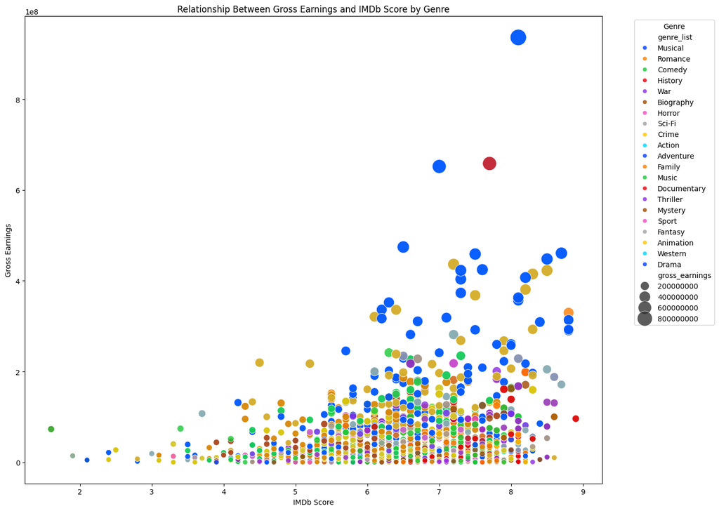

```python
# Preprocessing for the scatter plot
# Since genres are in lists, we need to explode this column to have one genre per row
movies_exploded_by_genre = movies_df.explode('genre_list')

# Scatter plot for the relationship between gross earnings and IMDb score, color-coded by genre
plt.figure(figsize=(14, 10))  # Set the figure size
# Create a scatter plot with IMDb score on the x-axis, gross earnings on the y-axis,
# genre determining color, and gross earnings determining the size of points
sns.scatterplot(x='imdb_score', y='gross_earnings', hue='genre_list', size='gross_earnings', sizes=(50, 500), data=movies_exploded_by_genre, palette='bright', alpha=0.8)
plt.title('Relationship Between Gross Earnings and IMDb Score by Genre')  # Set the title of the plot
plt.xlabel('IMDb Score')  # Label the x-axis
plt.ylabel('Gross Earnings')  # Label the y-axis
# Place the legend outside the plot area for clarity, specifying title and location
plt.legend(title='Genre', bbox_to_anchor=(1.05, 1), loc='upper left')
plt.tight_layout()  # Adjust layout to prevent clipping of labels
plt.show()  # Display the plot
```

## Heat Map Analysis

1. **User Ratings and IMDb Scores**: The high correlation between `imdb_score` and `average_user_rating` suggests that these two measures of movie success are closely aligned. This could mean that the criteria used by IMDb and the general audience to rate movies are similar.
2. **Gross Earnings and User Votes**: The positive correlation between `gross_earnings` and `num_user_votes` could indicate that more commercially successful movies also generate more viewer engagement in terms of voting.
3. **Movie Length and IMDb Scores**: The positive correlation between `runtime` and `imdb_score` suggests that longer movies tend to receive higher IMDb scores. This could be because longer movies have more time to develop plot and characters, which could lead to higher ratings.
4. **Recent Movies and Movie Length**: The negative correlation between `release_year` and `runtime` might suggest a trend towards shorter movies in more recent years. This could be due to changes in audience preferences or advancements in storytelling techniques that allow for more concise movies.

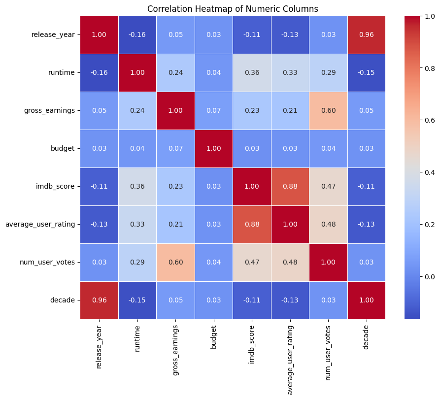

```python
# Heat map for correlation analysis among numerical features
# Calculate correlation for all numeric columns
correlation_matrix = movies_df.corr()

# Create a heatmap
plt.figure(figsize=(10, 8))  # Set the figure size
# Generate a heatmap with correlation values annotated, using coolwarm color palette,
# displaying correlation values rounded to two decimal places, and adding white lines between cells
sns.heatmap(correlation_matrix, annot=True, cmap='coolwarm', fmt=".2f", linewidths=.5)
plt.title('Correlation Heatmap of Numeric Columns')  # Set the title of the plot
plt.show()  # Display the plot
```

## Comedy Genre: A Brief Overview

The comedy genre is a delightful playground for filmmakers and audiences alike. It's a genre that transcends boundaries, from ancient Greek plays to modern-day sitcoms. Here are some key points about comedy:

1. **Definition**: The comedy genre aims to create humor and intentional laughs for the audience. Whether it's slapstick, wit, or dark humor, comedy serves as a universal language that brings joy and lightens our hearts.
2. **Charlie Chaplin**: Consider the legendary Charlie Chaplin, cinema's first great artist. His genius lay not only in making people laugh but also in evoking tears in the very next beat. Chaplin's ability to blend humor and pathos remains unmatched.
3. **Types of Comedy**: Comedy isn't a monolith; it comes in various flavors. Let's explore some subgenres:
   - **Raunchy/Blue Comedy**: Films like "The 40-Year-Old Virgin" and TV shows like "You're the Worst" thrive in the dirty comedy space. They embrace jokes about sex, relationships, and gross-out humor, often making us squirm and laugh simultaneously.
   - **Black or Dark Comedy**: This sophisticated form tackles taboo subjects like murder, sex, religion, and politics. Movies like "Arsenic and Old Lace" and Kubrick's brilliant "Dr. Strangelove" fall into this category. Darkly humorous yet daringly so, they make light of things we'd usually see in drama.
   - **Cringe Comedy**: Ever experienced schadenfreude—the pleasure derived from other people's pain? Cringe comedy thrives on awkward situations, making us squirm while secretly enjoying the discomfort.
   - **Deadpan Comedy**: Deadpan humor delivers some of the funniest lines. Think of deadpan delivery as the art of saying something absurd with a straight face. Dry wit at its finest!
   - **Mockumentary**: This genre parodies documentaries, often blurring the line between reality and absurdity. Shows like "The Office" and "This Is Spinal Tap" fall into this category.
   - **Wordplay Comedy**: Clever wordplay, puns, and linguistic acrobatics create laughter. Think of Oscar Wilde's witty plays or the banter in "His Girl Friday."
4. **Masterpieces**: Some comedy films stand the test of time:
   - **"Arsenic and Old Lace" (1944)**: A black comedy that finds humor in murder.
   - **"Dr. Strangelove" (1964)**: A darkly hilarious take on the Cold War and nuclear apocalypse.
   - **"Monsieur Verdoux" (1947)**: Chaplin's unsettling black comedy that defied conventions.
   - **"A Clockwork Orange" (1971)**: Kubrick's controversial blend of satire and dark humor.

Source: (1) Mastering the Comedy Genre in Movies and TV - No Film School. https://nofilmschool.com/comedy-genre. (2) Types of Comedy Genres, Explained - The Cinemaholic. https://thecinemaholic.com/sub-genres-of-comedy-explained/. (3) Comedy film - Wikipedia. https://en.wikipedia.org/wiki/Comedy_film. (4) The Ultimate Movie Genres List: 90+ Genre Examples for Film & TV. https://www.studiobinder.com/blog/movie-genres-list/. (5) What is Comedy? Definition, Techniques, and Examples - StudioBinder. https://www.studiobinder.com/blog/what-is-comedy-definition/.

## Conclusion

The Comedy genre's ability to adapt, reflect, and challenge societal norms, combined with its enduring appeal and financial viability, underscores its significant impact on cinema and culture. This analysis has revealed not only the quantitative aspects of Comedy movies' performances but also the qualitative aspects that contribute to their enduring popularity and influence.

Through the lens of Comedy, we can see the evolution of societal attitudes, the power of laughter as a unifying force, and the creativity and innovation that filmmakers bring to the genre. As we continue to navigate changing social landscapes, Comedy remains a vital, reflective, and entertaining genre that speaks to the human condition with humor and heart.

This exploration of the Comedy genre, from its trends over time to its key qualitative aspects, provides valuable insights for stakeholders interested in understanding its role in the film industry and its appeal to audiences worldwide.

```python
#THANK YOU
```